# ANOVA para el crecimiento de plantas, por especie y tratamiento, entre la semanas 9 y 10

Santiago Francisco Robles Tamayo

2023-05-26

**Planteamiento del problema**

1. Comparar el estatus micorrícico entre las plantas establecidas en el jal y las mismas especies de plantas en suelo natural.
2. Evaluar la influencia del inóculo de micorrizas en dos especies tolerantes a las condiciones del jal de Nacozari a diferentes tratamientos.

**Objetivo del proyecto**

Hacer un análisis de varianza del crecimiento de las plantas entre las semanas 9 y 10, por tratamiento y especie.

**¿Qué es un ANOVA?**

- La técnica de análisis de varianza (ANOVA), también conocida como análisis factorial y desarrollada por Fisher en 1930, constituye la herramienta básica para el estudio del efecto de uno o más factores (cada uno con dos o más niveles) sobre la media de una variable continua.
- Se hace uso de esta prueba estadística cuando se desean comparar las medias de dos o más grupos. Esta técnica puede generalizarse también para estudiar los posibles efectos de los factores sobre la varianza de una variable.
- Ho = la media de la variable estudiada es la misma en los diferentes grupos.
- H1 = al menos dos medias difieren de forma significativa

**Cargar la base de datos**

```r
library(tidyr)
library(readr)
library(readxl)

data <- read_excel("dif_semanal.xlsx")
r_communis <- read_excel("dif_semanal_rcommunis_2.xlsx")
v_farnesiana <- read_excel("dif_semanal_Vfarnesiana_2.xlsx")

# total de diferencias de crecimiento por planta y tratamiento
data = as.data.frame(data)

# r communis, crecimeinto semana 4-3
r_communis = as.data.frame(r_communis)
r_communis
```

```
##    Réplica     Especie Tratamiento H10_H9
## 1        5 R. communis           C    0.5
## 2        8 R. communis           C    1.5
## 3        9 R. communis           C    1.5
## 4       14 R. communis           C    0.5
## 5       15 R. communis           C    1.5
## 6       16 R. communis           C    1.0
## 7       17 R. communis           C    2.0
## 8       18 R. communis           C    1.5
## 9       22 R. communis           J    0.0
## 10      23 R. communis           J    0.5
## 11      33 R. communis           J    0.0
## 12      48 R. communis          JI    0.0
## 13      58 R. communis          JI    0.0
## 14      59 R. communis          JI    0.0
```

[output cut: 18 more lines]

```r
# v. farnesiana, crecimiento semana 4-3
v_farnesiana = as.data.frame(v_farnesiana)
v_farnesiana
```

```
##    Réplica       Especie Tratamiento H10_H9
## 1        1 V. farnesiana           C    0.5
## 2        2 V. farnesiana           C    4.5
## 3        4 V. farnesiana           C    6.0
## 4       10 V. farnesiana           C    4.5
## 5       11 V. farnesiana           C    7.0
## 6       12 V. farnesiana           C    2.5
## 7       13 V. farnesiana           C    4.5
## 8       19 V. farnesiana           C    3.5
## 9       20 V. farnesiana           C    4.5
## 10      21 V. farnesiana           J    0.0
## 11      28 V. farnesiana           J    0.0
## 12      30 V. farnesiana           J    1.0
## 13      35 V. farnesiana           J    0.0
## 14      38 V. farnesiana           J    0.5
```

[output cut: 24 more lines]

**Verificar condiciones para un ANOVA**

- **Diagrama de caja**: Este tipo de representación permite identificar de forma preliminar si existen asimetrías, datos atípicos o diferencia de varianzas. En este caso, los 5 tratamientos no parecen seguir una distribución simétrica para ambas especies de plantas. En el gráfico *R. Communis*, el tratamiento Suelo Natural (SN) tiene un valor atípico<; en el gráfico *v.Farnesisna*, los tratamientos *Composta*, *Composta con inóculo* y *Jal con inóculo* también muestran valores atípicos.

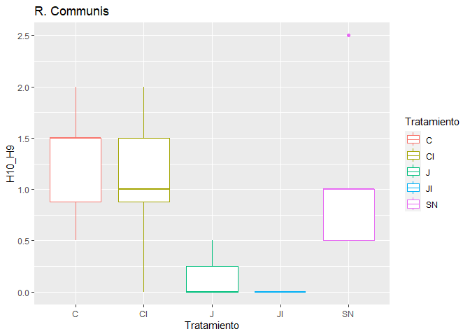

```r
#R. Communis
library(ggplot2)
ggplot(data = r_communis, aes(x = Tratamiento, y = H10_H9, color = Tratamiento)) +
    geom_boxplot() +
  ggtitle("R. Communis")
```

```r
    theme_bw()
```

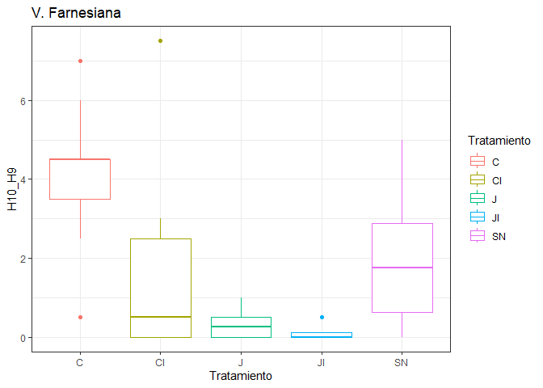

```r
#V. Farnesiana
ggplot(data = v_farnesiana, aes(x = Tratamiento, y = H10_H9, color = Tratamiento)) +
    geom_boxplot() +
  ggtitle("V. Farnesiana") +
    theme_bw()
```

- **Distribución normal de las observaciones**: La variable cuantitativa debe de distribuirse de forma normal en cada uno de los grupos. El estudio de normalidad puede hacerse de forma gráfica (qqplot) o con prueba de hipótesis. **Si las dos distribuciones que estamos comparando son exactamente iguales, entonces los puntos en el Q-Qplot mostrarán una linea recta donde x=y**.

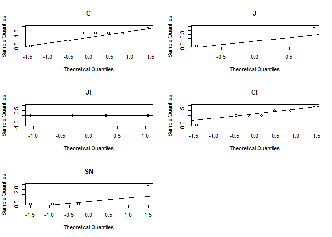

```r
# R. communis
par(mfrow = c(3,2))
qqnorm(r_communis[r_communis$Tratamiento == "C","H10_H9"], main = "C")
qqline(r_communis[r_communis$Tratamiento == "C","H10_H9"])

qqnorm(r_communis[r_communis$Tratamiento == "J","H10_H9"], main = "J")
qqline(r_communis[r_communis$Tratamiento == "J","H10_H9"])

qqnorm(r_communis[r_communis$Tratamiento == "JI","H10_H9"], main = "JI")
qqline(r_communis[r_communis$Tratamiento == "JI","H10_H9"])

qqnorm(r_communis[r_communis$Tratamiento == "CI","H10_H9"], main = "CI")
qqline(r_communis[r_communis$Tratamiento == "CI","H10_H9"])

qqnorm(r_communis[r_communis$Tratamiento == "SN","H10_H9"], main = "SN")
qqline(r_communis[r_communis$Tratamiento == "SN","H10_H9"])
```

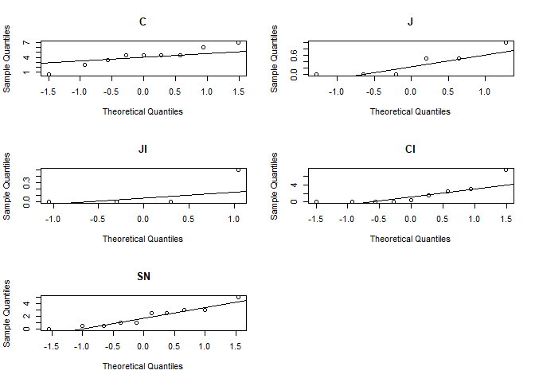

```r
# V. farnesiana
par(mfrow = c(3,2))
qqnorm(v_farnesiana[v_farnesiana$Tratamiento == "C","H10_H9"], main = "C")
qqline(v_farnesiana[v_farnesiana$Tratamiento == "C","H10_H9"])

qqnorm(v_farnesiana[v_farnesiana$Tratamiento == "J","H10_H9"], main = "J")
qqline(v_farnesiana[v_farnesiana$Tratamiento == "J","H10_H9"])

qqnorm(v_farnesiana[v_farnesiana$Tratamiento == "JI","H10_H9"], main = "JI")
qqline(v_farnesiana[v_farnesiana$Tratamiento == "JI","H10_H9"])

qqnorm(v_farnesiana[v_farnesiana$Tratamiento == "CI","H10_H9"], main = "CI")
qqline(v_farnesiana[v_farnesiana$Tratamiento == "CI","H10_H9"])

qqnorm(v_farnesiana[v_farnesiana$Tratamiento == "SN","H10_H9"], main = "SN")
qqline(v_farnesiana[v_farnesiana$Tratamiento == "SN","H10_H9"])
```

Dado que los grupos tienen menos 50 eventos, se emplea el test Shapiro-Wilk. Si fuesen más de 50 eventos por grupo, se emplearía el test de Kolmogorov-Smirnov, con la corrección de Lilliefors que se encuentra en el paquete nortest.

**Prueba Kolmogorov-Smirnov**

- Se aplica para conocer la falta de normalidad.
- Ho = La muestra no tiene una distribución normal
- H1 = La muestra tiene una distribución normal

```r
library(nortest)

# R. communis
#by(data = r_communis,INDICES = r_communis$Tratamiento,FUN = function(x){ lillie.test(x$H10_H9)})


# v. farnesiana
#by(data = v_farnesiana,INDICES = v_farnesiana$Tratamiento,FUN = function(x){ lillie.test(x$H10_H9)})
```

**Prueba Shapiro wilk**

- Se usa para contrastar normalidad de un conjunto de datos.
- Ho = La muestra tiene una distribución normal
- H1 = La muestra no tiene una distribución normal

```r
# R. Communis

shapiro.test(r_communis$H10_H9)
```

```
##
##  Shapiro-Wilk normality test
##
## data:  r_communis$H10_H9
## W = 0.91713, p-value = 0.0174
```

```r
#V. Farnesiana
shapiro.test(v_farnesiana$H10_H9)
```

```
##
##  Shapiro-Wilk normality test
##
## data:  v_farnesiana$H10_H9
## W = 0.83741, p-value = 6.659e-05
```

**Test de Levene**

- También puede corroborarse normalidad de las varianzas. El supuesto de homogeneidad de varianzas, también conocido como supuesto de homocedasticidad, considera que la varianza es constante (no varía) en los diferentes niveles de un factor, es decir, entre diferentes grupos.
- Una de las pruebas para corroborar este supuesto es Levene. Se caracteriza, además de por poder comparar 2 o más poblaciones, por permitir elegir entre diferentes estadísticos de centralidad :mediana (por defecto), media, media truncada. Esto es importante a la hora de contrastar la homocedasticidad dependiendo de si los grupos se distribuyen de forma normal o no.
- Ho = las varianzas poblacionales son iguales (llamado homogeneidad de varianza u homocedasticidad)
- H1 = hay una diferencia entre las variaciones en la población

```r
# leveneTest(y = iris$Petal.Length, group = iris$Species, center = "median")

# R.Communis
library(car)
leveneTest(y = r_communis$H10_H9, group = r_communis$Tratamiento, center = "median")
```

```
## Levene's Test for Homogeneity of Variance (center = "median")
##       Df F value Pr(>F)
## group  4  0.9515 0.4498
##       27
```

```r
# V. Farnesiana
leveneTest(y = v_farnesiana$H10_H9, group = v_farnesiana$Tratamiento, center = "median")
```

```
## Levene's Test for Homogeneity of Variance (center = "median")
##       Df F value Pr(>F)
## group  4  1.4124 0.2515
##       33
```

**Análisis de varianza (ANOVA)**

- Se hace uso de esta prueba estadística cuando se desean comparar las medias de dos o más grupos. Esta técnica puede generalizarse también para estudiar los posibles efectos de los factores sobre la varianza de una variable.
- Ho = la media de la variable estudiada es la misma en los diferentes grupos.
- H1 = al menos dos medias difieren de forma significativa

```r
anova_r_communis <- aov(r_communis$H10_H9 ~ r_communis$Tratamiento)
summary(anova_r_communis)
```

```
##                        Df Sum Sq Mean Sq F value  Pr(>F)
## r_communis$Tratamiento  4  6.010  1.5024   5.003 0.00378 **
## Residuals              27  8.108  0.3003
## ---
## Signif. codes:  0 '***' 0.001 '**' 0.01 '*' 0.05 '.' 0.1 ' ' 1
```

```r
anova_v_farnesiana <- aov(v_farnesiana$H10_H9 ~ v_farnesiana$Tratamiento)
summary(anova_v_farnesiana)
```

```
##                          Df Sum Sq Mean Sq F value   Pr(>F)
## v_farnesiana$Tratamiento  4  73.97  18.493   6.077 0.000887 ***
## Residuals                33 100.42   3.043
## ---
## Signif. codes:  0 '***' 0.001 '**' 0.01 '*' 0.05 '.' 0.1 ' ' 1
```

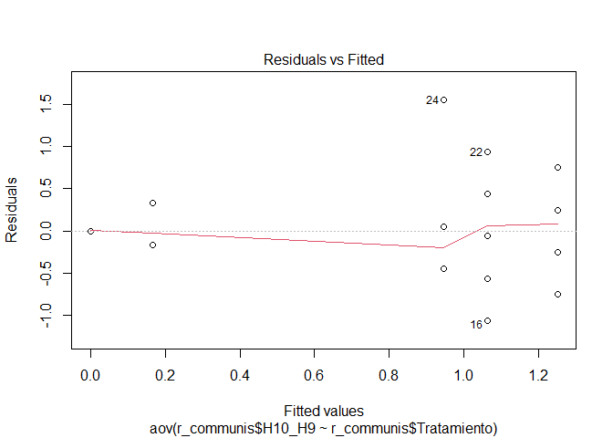

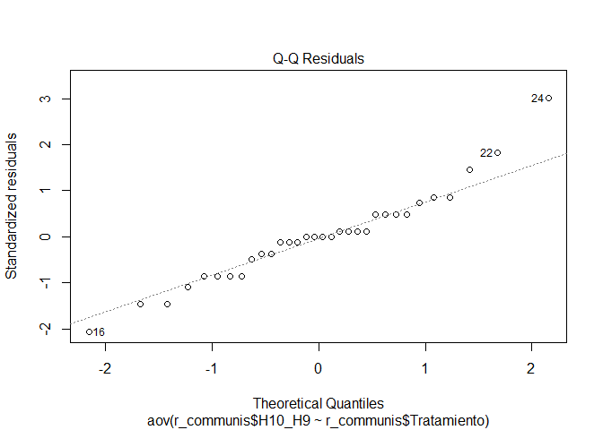

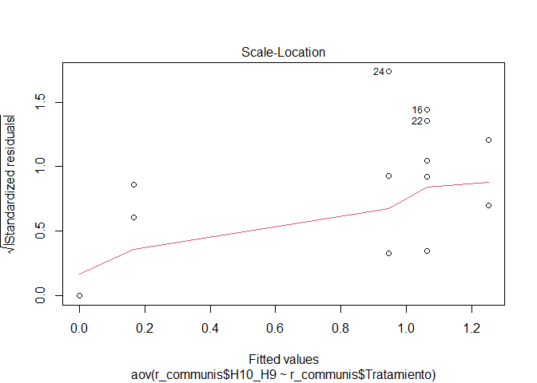

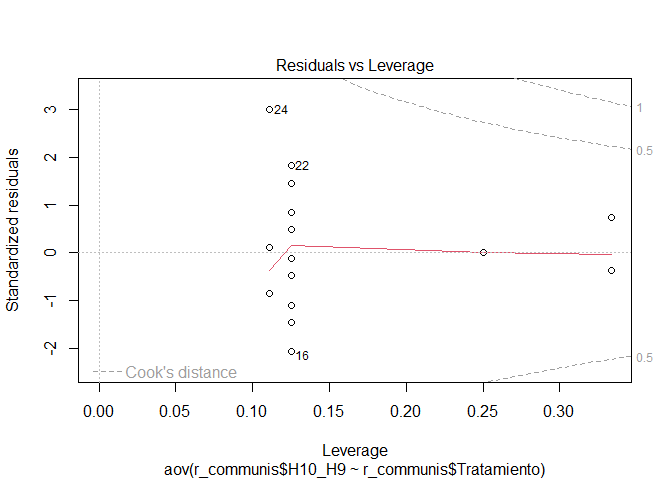

```r
plot(anova_r_communis)
```

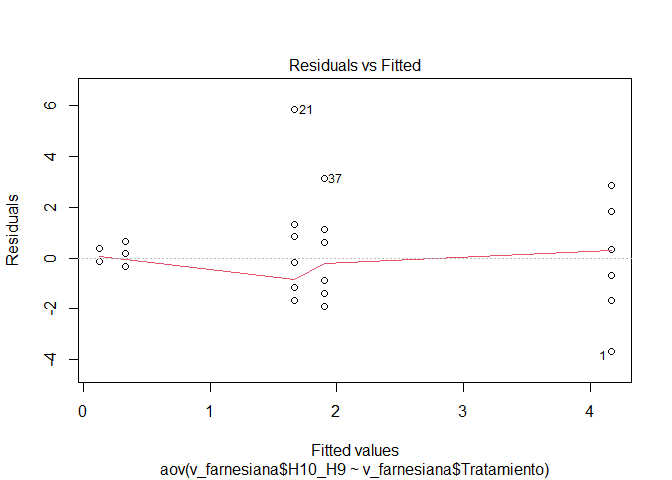

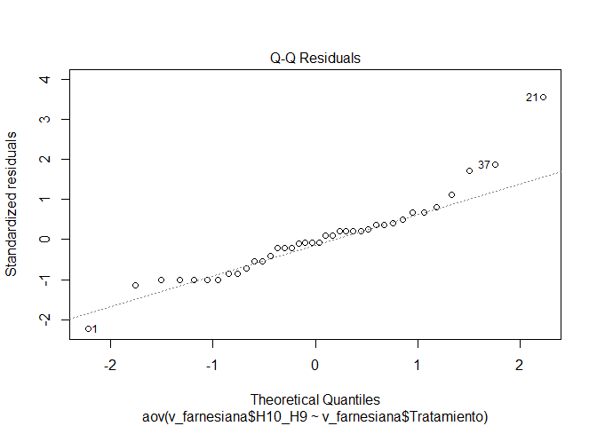

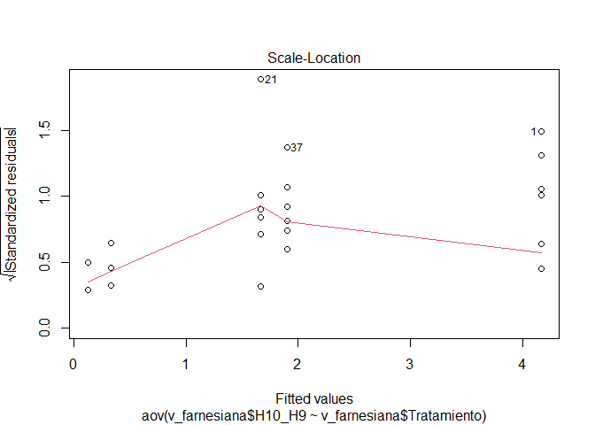

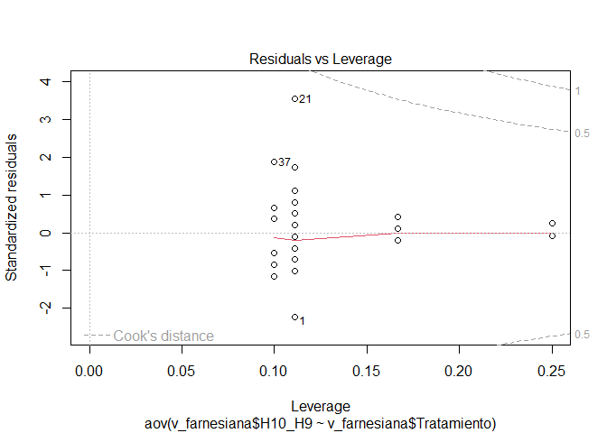

```r
plot(anova_v_farnesiana)
```

**Tukey’s test**

```r
# R. Communis

TukeyHSD(anova_r_communis)
```

```
##   Tukey multiple comparisons of means
##     95% family-wise confidence level
##
## Fit: aov(formula = r_communis$H10_H9 ~ r_communis$Tratamiento)
##
## $`r_communis$Tratamiento`
##             diff         lwr           upr     p adj
## CI-C  -0.1875000 -0.98773883  0.6127388253 0.9581786
## J-C   -1.0833333 -2.16686182  0.0001951583 0.0500580
## JI-C  -1.2500000 -2.23008840 -0.2699116028 0.0074605
## SN-C  -0.3055556 -1.08324790  0.4721367936 0.7800966
## J-CI  -0.8958333 -1.97936182  0.1876951583 0.1419866
## JI-CI -1.0625000 -2.04258840 -0.0824116028 0.0286975
## SN-CI -0.1180556 -0.89574790  0.6596367936 0.9915261
## JI-J  -0.1666667 -1.38905166  1.0557183303 0.9943743
## SN-J   0.7777778 -0.28920732  1.8447628782 0.2373601
## SN-JI  0.9444444 -0.01732293  1.9062118169 0.0561079
```

```r
#V. Farnesiana
TukeyHSD(anova_v_farnesiana)
```

```
##   Tukey multiple comparisons of means
##     95% family-wise confidence level
##
## Fit: aov(formula = v_farnesiana$H10_H9 ~ v_farnesiana$Tratamiento)
##
## $`v_farnesiana$Tratamiento`
##             diff       lwr         upr     p adj
## CI-C  -2.5000000 -4.871874 -0.12812614 0.0347443
## J-C   -3.8333333 -6.485169 -1.18149774 0.0018196
## JI-C  -4.0416667 -7.065224 -1.01810889 0.0043110
## SN-C  -2.2666667 -4.578483  0.04515001 0.0568375
## J-CI  -1.3333333 -3.985169  1.31850226 0.6007597
## JI-CI -1.5416667 -4.565224  1.48189111 0.5880177
## SN-CI  0.2333333 -2.078483  2.54515001 0.9983486
## JI-J  -0.2083333 -3.456155  3.03948871 0.9997234
## SN-J   1.5666667 -1.031591  4.16492430 0.4250284
## SN-JI  1.7750000 -1.201678  4.75167807 0.4361570
```

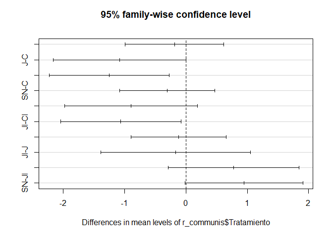

```r
# R. Communis
plot(TukeyHSD(anova_r_communis))
```

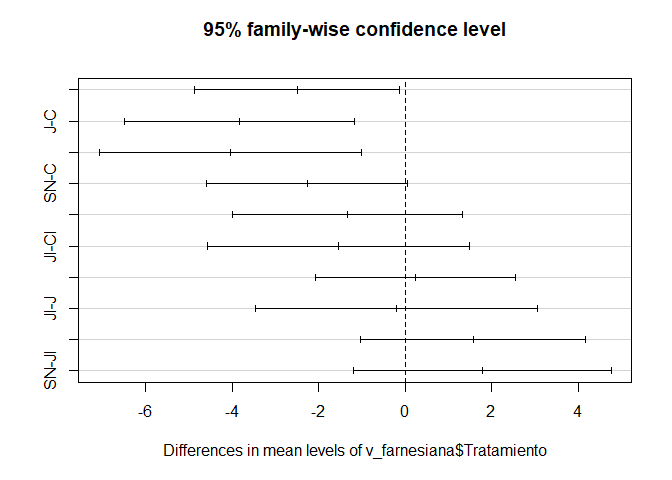

```r
# V. Farnesiana
plot(TukeyHSD(anova_v_farnesiana))
```

**Referencias**

- [Análisis de la homogeneidad de varianza (homocedasticidad)](https://rpubs.com/Joaquin_AR/218466)
- [ANOVA análisis de varianza para comparar múltiples medias](https://rpubs.com/Joaquin_AR/219148)
- [Pretydoc](https://prettydoc.statr.me/)
- [Prueba de Kolmogórov-Smirnov](https://es.wikipedia.org/wiki/Prueba_de_Kolmog%C3%B3rov-Smirnov)
- [PRUEBA DE SHAPIRO-WILK](https://rpubs.com/RubenOrtiz/192363)
- [Prueba de Shapiro–Wilk](https://es.wikipedia.org/wiki/Prueba_de_Shapiro%E2%80%93Wilk)
- [QQplots explained](https://towardsdatascience.com/q-q-plots-explained-5aa8495426c0)
- [R markdown cookbook, Chunk options, Hide code](https://bookdown.org/yihui/rmarkdown-cookbook/hide-one.html)
- [Rmarkdown: The definitive guide](https://bookdown.org/yihui/rmarkdown/)